# Predicting Product XYZ Test Modes with 99.9% Posterior Predictive Intervals, A use case for time savings by implementing predictive analytics

Logan Balaich

8/22/2020

# Overview

Product XYZ before this analysis would undergo extensive testing. For each kind of test there were also several modes to be tested for each test. You can think of it like unto the camera on your phone, it can take pictures using the front camera, the back camera, in portrait mode, landscape mode etc. Each of those modes on your phone camera is still taking a picture, but just in a different mode. For product XYZ each mode for each test has specification limits that must be met in order to pass the test.

The goal of this analysis is to provide insight as to which test modes can be predicted with a 99.9% probability of passing the remaining test modes within spec. Thus eliminating the need for testing Product XYZ in every mode for all tests.

Bayesian methods were used in conjunction with the supervised machine learning statistical package ‘rstan’ to provide these predictions. All predictions come with a 99.9% posterior predictive interval (also called a credible interval).

There are several tests for Product XYZ to pass to meet the quality standards required. This document and code will only show the analysis for one test. The exact same method was applied for all other tests.

## Test A

For the Product XYZ test A consists of four modes (Mode 0, Mode 1, Mode 2 and Mode 3). The analysis method is to take observed data from Mode 0 and see how well we can predict Modes 1, 2, and 3.

### Predicting Mode 1 Test A from Mode 0 Test A

The below scatterplot and correlation value shows there is a strong positive correlation between Mode 0 Test A and Mode 1 Test A.

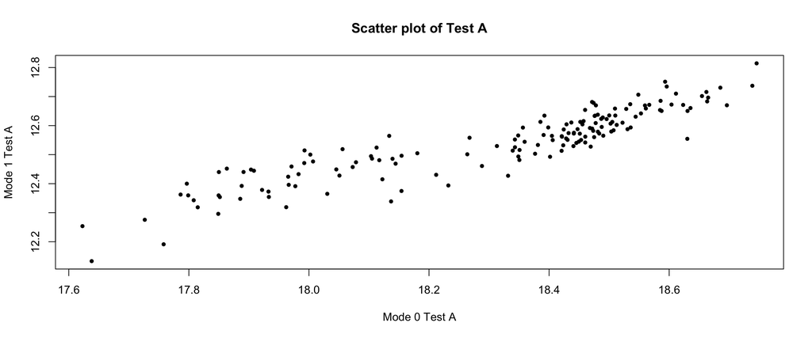

```
## [1] 0.9089494
```

From Mode 0 data a model was constructed to provide Mode 1 Test A predictions with a 99.9% posterior predictive interval. Below is a graph which takes the data points from the previous scatter plot and overlays it with predictions and the predictive intervals.

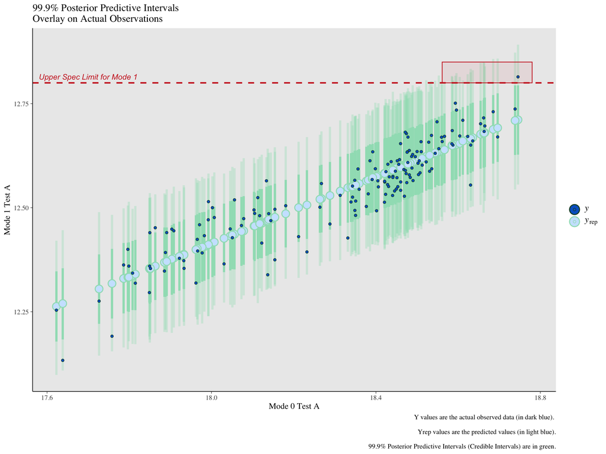

From this plot we see there are a few predictive intervals which go above spec, therefore a cutoff value has been calculated so we know exactly at which point our 99.9% probability of staying within spec will end.  
Cutoff value:

```
## [1] 18.56116
```

### Predicting Mode 2 Test A from Mode 0 Test A

The below scatterplot and correlation value shows there is a strong positive correlation between Mode 0 Test A and Mode 2 Test A.

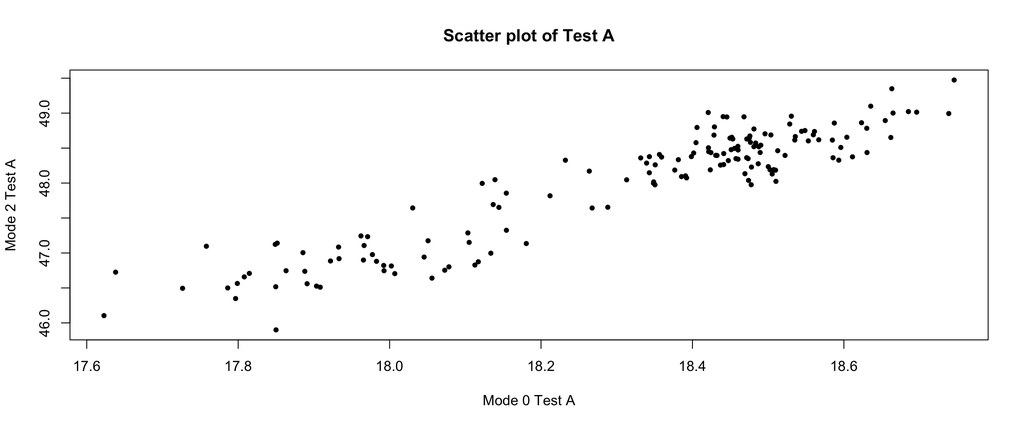

```
## [1] 0.9319645
```

From Mode 0 data a model was constructed to provide Mode 2 Test A predictions with a 99.9% posterior predictive interval. Below is a graph which takes the data points from the previous scatter plot and overlays it with predictions and the predictive intervals.

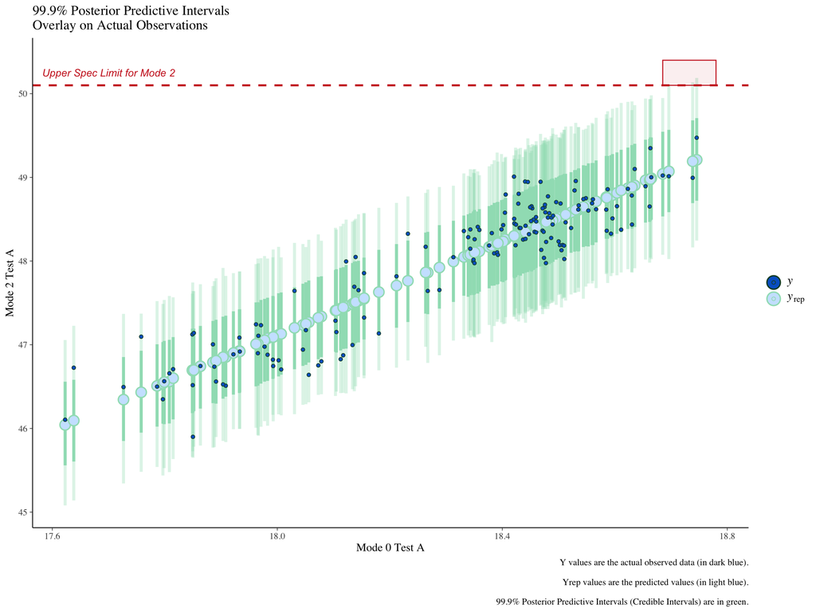

From this plot we see there are a few predictive intervals which go above spec, therefore a cutoff value has been calculated so we know exactly at which point our 99.9% probability of staying within spec will end.  
Cutoff value:

```
## [1] 18.68525
```

### Predicting Mode 3 Test A from Mode 0 Test A

The below scatterplot and correlation value shows there is a strong positive correlation between Mode 0 Test A and Mode 3 Test A.

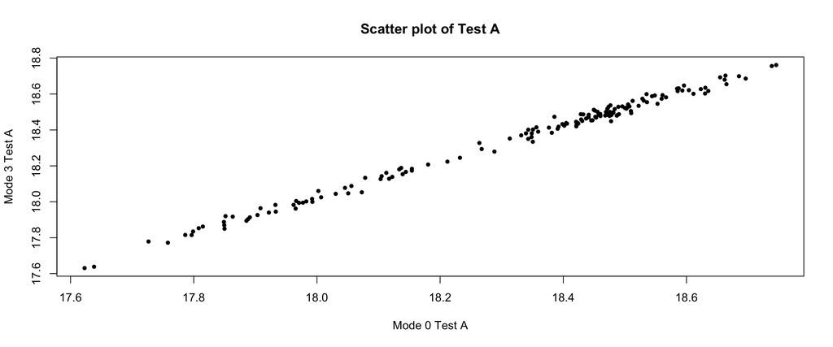

```
## [1] 0.9969626
```

From Mode 0 data a model was constructed to provide Mode 3 Test A predictions with a 99.9% posterior predictive interval. Below is a graph which takes the data points from the previous scatter plot and overlays it with predictions and the predictive intervals.

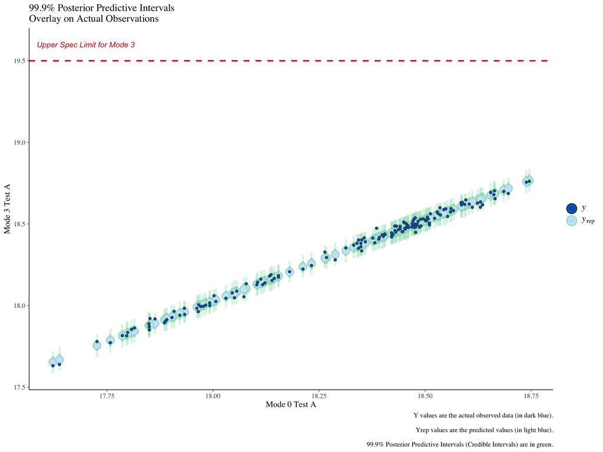